# Maps in R – Examples

From http://geography.uoregon.edu/geogr/topics/maps.htm

The examples here use several libraries, datasets, and shapefiles that should be downloaded and/or installed, and read in before proceeding. This will make the examples easier to follow, but they will fail if the data sets do not exist or have not been read in. For one of the example data sets, Oregon climate-station data, the data are available in two forms–as a .csv file (orstation.csv), and included as part of the orstations shape file. as a consequence, the individual variables will be referred to by their “full” names (e.g. `orstationc$tann`).

Required libraries: `maptools` (and `sp`), `rgdal`, `RColorBrewer`, `classInt`, `maps`, `gpclib`

Data sets: [orstationc.csv] – Oregon climate station data (includes lat and lon) [orcountyp.csv] – Oregon county census data (includes lats and lons, but not outlines) [cities2.csv] – Large cities data set, with country names added

Load the libraries:

```r
library(gpclib)
```

[output not shown]

```r
library(maptools)  # loads sp library too
library(RColorBrewer)  # creates nice color schemes
library(classInt)  # finds class intervals for continuous variables
```

To enable the polygon-clipping library, type:

```r
gpclibPermit()
```

```
## [1] FALSE
```

```r
# outlines of Oregon counties (lines) browse to orotl.shp
orotl.shp <- readShapeLines("Shapefiles/orotl.shp", proj4string = CRS("+proj=longlat"))

# Oregon climate station data (points) browse to orstations.shp
orstations.shp <- readShapePoints("Shapefiles/orstations.shp", proj4string = CRS("+proj=longlat"))

# Oregon county census data (polygons) browse to orcounty.shp
orcounty.shp <- readShapePoly("Shapefiles/orcounty.shp", proj4string = CRS("+proj=longlat"))
```

Read ordinary rectangular data sets:

```r
orstationc <- read.csv("Data/orstationc.csv")
orcountyp <- read.csv("Data/orcountyp.csv")
cities <- read.csv("Data/cities2.csv")
```

Examine the structure and contents of orcounty.shp shapefile:

```r
summary(orcounty.shp)
```

[output not shown]

[output cut: 57 more lines]

[output not shown]

```r
attributes(orcounty.shp)
```

[output not shown]

[output cut: 3440 more lines]

```r
attributes(orcounty.shp@data)
```

```
## $names
##  [1] "NAME"       "STATE_NAME" "STATE_FIPS" "CNTY_FIPS"  "FIPS"
##  [6] "AREA"       "POP1990"    "POP1997"    "POP90_SQMI" "HOUSEHOLDS"
## [11] "MALES"      "FEMALES"    "WHITE"      "BLACK"      "AMERI_ES"
## [16] "ASIAN_PI"   "OTHER"      "HISPANIC"   "AGE_UNDER5" "AGE_5_17"
## [21] "AGE_18_29"  "AGE_30_49"  "AGE_50_64"  "AGE_65_UP"  "NEVERMARRY"
## [26] "MARRIED"    "SEPARATED"  "WIDOWED"    "DIVORCED"   "HSEHLD_1_M"
## [31] "HSEHLD_1_F" "MARHH_CHD"  "MARHH_NO_C" "MHH_CHILD"  "FHH_CHILD"
## [36] "HSE_UNITS"  "VACANT"     "OWNER_OCC"  "RENTER_OCC" "MEDIAN_VAL"
## [41] "MEDIANRENT" "UNITS_1DET" "UNITS_1ATT" "UNITS2"     "UNITS3_9"
## [46] "UNITS10_49" "UNITS50_UP" "MOBILEHOME" "NO_FARMS87" "AVG_SIZE87"
## [51] "CROP_ACR87" "AVG_SALE87"
##
## $row.names
##  [1] "0"  "1"  "2"  "3"  "4"  "5"  "6"  "7"  "8"  "9"  "10" "11" "12" "13"
## [15] "14" "15" "16" "17" "18" "19" "20" "21" "22" "23" "24" "25" "26" "27"
## [29] "28" "29" "30" "31" "32" "33" "34" "35"
##
## $class
## [1] "data.frame"
##
## $data_types
##  [1] "C" "C" "C" "C" "C" "N" "N" "N" "N" "N" "N" "N" "N" "N" "N" "N" "N"
## [18] "N" "N" "N" "N" "N" "N" "N" "N" "N" "N" "N" "N" "N" "N" "N" "N" "N"
## [35] "N" "N" "N" "N" "N" "N" "N" "N" "N" "N" "N" "N" "N" "N" "N" "N" "N"
## [52] "N"
```

```r
attr(orcounty.shp, "polygons")
```

[output not shown]

[output cut: 3079 more lines]

[output not shown]

## 1. Some simple maps

R has the capability of plotting some simple maps using the `maptools` package, which can read and plot ESRI shapefiles. Here are a couple of examples:

Oregon county census data – attribute data in the `orcounty.shp` shape file

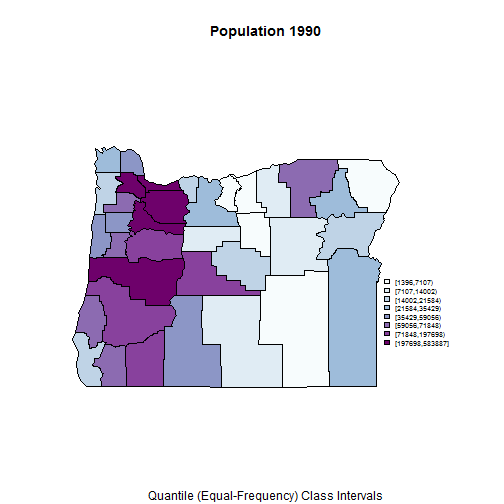

```r
# equal-frequency class intervals
plotvar <- orcounty.shp@data$POP1990
nclr <- 8
plotclr <- brewer.pal(nclr, "BuPu")
class <- classIntervals(plotvar, nclr, style = "quantile")
colcode <- findColours(class, plotclr)

plot(orcounty.shp, xlim = c(-124.5, -115), ylim = c(42, 47))
plot(orcounty.shp, col = colcode, add = T)
title(main = "Population 1990", sub = "Quantile (Equal-Frequency) Class Intervals")
legend(-117, 44, legend = names(attr(colcode, "table")), fill = attr(colcode,
    "palette"), cex = 0.6, bty = "n")
```

Oregon climate station data – data in the `orstationc.csv` file, basemap in `orotl.shp`

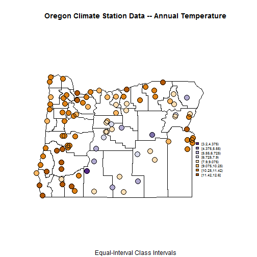

```r
# symbol plot -- equal-interval class intervals
plotvar <- orstationc$tann
nclr <- 8
plotclr <- brewer.pal(nclr, "PuOr")
plotclr <- plotclr[nclr:1]  # reorder colors
class <- classIntervals(plotvar, nclr, style = "equal")
colcode <- findColours(class, plotclr)

plot(orotl.shp, xlim = c(-124.5, -115), ylim = c(42, 47))
points(orstationc$lon, orstationc$lat, pch = 16, col = colcode, cex = 2)
points(orstationc$lon, orstationc$lat, cex = 2)
title("Oregon Climate Station Data -- Annual Temperature", sub = "Equal-Interval Class Intervals")
legend(-117, 44, legend = names(attr(colcode, "table")), fill = attr(colcode,
    "palette"), cex = 0.6, bty = "n")
```

Oregon climate station data – locations and data in shape file

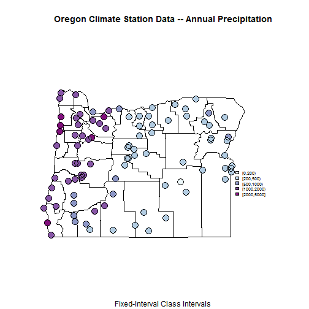

```r
# symbol plot -- equal-interval class intervals
plotvar <- orstations.shp@data$pann
nclr <- 5
plotclr <- brewer.pal(nclr, "BuPu")
class <- classIntervals(plotvar, nclr, style = "fixed", fixedBreaks = c(0, 200,
    500, 1000, 2000, 5000))
colcode <- findColours(class, plotclr)
orstations.pts <- orstations.shp@coords  # get point data

plot(orotl.shp, xlim = c(-124.5, -115), ylim = c(42, 47))
points(orstations.pts, pch = 16, col = colcode, cex = 2)
points(orstations.pts, cex = 2)
title("Oregon Climate Station Data -- Annual Precipitation", sub = "Fixed-Interval Class Intervals")
legend(-117, 44, legend = names(attr(colcode, "table")), fill = attr(colcode,
    "palette"), cex = 0.6, bty = "n")
```

## 2. Variations in color scales and representation

This set of examples illustrates some more applications of the `maptools` package, and some variations in the contruction of class intervals for choropleth maps and symbolic representation of the Oregon county-level census data

Oregon county census data – equal-frequency class intervals

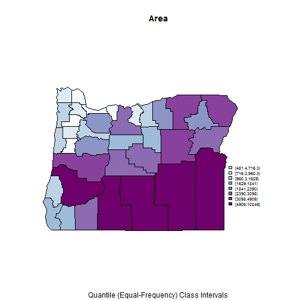

```r
# equal-frequency class intervals
plotvar <- orcounty.shp@data$AREA
nclr <- 8
plotclr <- brewer.pal(nclr, "BuPu")
# plotclr <- plotclr[nclr:1] # reorder colors if appropriate
class <- classIntervals(plotvar, nclr, style = "quantile")
colcode <- findColours(class, plotclr)

plot(orcounty.shp, xlim = c(-124.5, -115), ylim = c(42, 47))
plot(orcounty.shp, col = colcode, add = T)
title(main = "Area", sub = "Quantile (Equal-Frequency) Class Intervals")
legend(-117, 44, legend = names(attr(colcode, "table")), fill = attr(colcode,
    "palette"), cex = 0.6, bty = "n")
```

Oregon county census data – equal-width class intervals

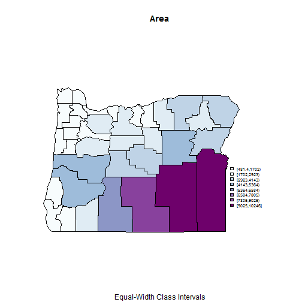

```r
# equal-width class intervals of county area
plotvar <- orcounty.shp@data$AREA
nclr <- 8
plotclr <- brewer.pal(nclr, "BuPu")
# plotclr <- plotclr[nclr:1] # reorder colors if appropriate
class <- classIntervals(plotvar, nclr, style = "equal")
colcode <- findColours(class, plotclr)

plot(orcounty.shp, xlim = c(-124.5, -115), ylim = c(42, 47))
plot(orcounty.shp, col = colcode, add = T)
title(main = "Area", sub = " Equal-Width Class Intervals")
legend(-117, 44, legend = names(attr(colcode, "table")), fill = attr(colcode,
    "palette"), cex = 0.6, bty = "n")
```

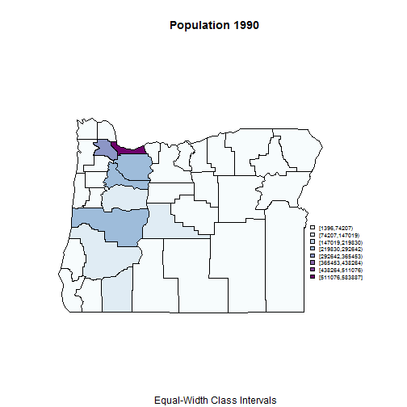

```r
# equal-width class intervals of 1990 population
plotvar <- orcounty.shp@data$POP1990
nclr <- 8
plotclr <- brewer.pal(nclr, "BuPu")
# plotclr <- plotclr[nclr:1] # reorder colors if appropriate
class <- classIntervals(plotvar, nclr, style = "equal")
colcode <- findColours(class, plotclr)

plot(orcounty.shp, xlim = c(-124.5, -115), ylim = c(42, 47))
plot(orcounty.shp, col = colcode, add = T)
title(main = "Population 1990", sub = " Equal-Width Class Intervals")
legend(-117, 44, legend = names(attr(colcode, "table")), fill = attr(colcode,
    "palette"), cex = 0.6, bty = "n")
```

Oregon county census data – bubble plots

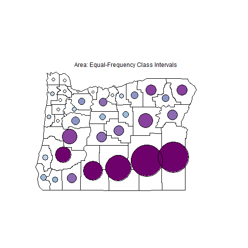

```r
# bubble plot equal-frequency class intervals
plotvar <- orcounty.shp@data$AREA
nclr <- 8
plotclr <- brewer.pal(nclr, "BuPu")
# plotclr <- plotclr[nclr:1] # reorder colors if appropriate
max.symbol.size = 12
min.symbol.size = 1
class <- classIntervals(plotvar, nclr, style = "quantile")
colcode <- findColours(class, plotclr)
symbol.size <- ((plotvar - min(plotvar))/(max(plotvar) - min(plotvar)) * (max.symbol.size -
    min.symbol.size) + min.symbol.size)

plot(orcounty.shp, xlim = c(-124.5, -115), ylim = c(42, 47))
orcounty.cntr <- coordinates(orcounty.shp)
points(orcounty.cntr, pch = 16, col = colcode, cex = symbol.size)
points(orcounty.cntr, cex = symbol.size)
text(-120, 46.5, "Area: Equal-Frequency Class Intervals")
```

```r
legend(locator(1), legend = names(attr(colcode, "table")), fill = attr(colcode,
    "palette"), cex = 0.6, bty = "n")
```

[output not shown]

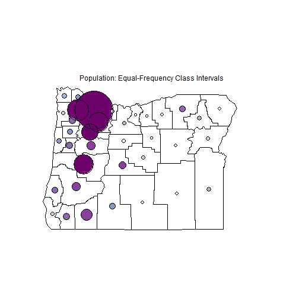

```r
# bubble plot equal-frequency class intervals
plotvar <- orcounty.shp@data$POP1990
nclr <- 8
plotclr <- brewer.pal(nclr, "BuPu")
# plotclr <- plotclr[nclr:1] # reorder colors if appropriate
max.symbol.size = 12
min.symbol.size = 1
class <- classIntervals(plotvar, nclr, style = "quantile")
colcode <- findColours(class, plotclr)
symbol.size <- ((plotvar - min(plotvar))/(max(plotvar) - min(plotvar)) * (max.symbol.size -
    min.symbol.size) + min.symbol.size)

plot(orcounty.shp, xlim = c(-124.5, -115), ylim = c(42, 47))
orcounty.cntr <- coordinates(orcounty.shp)
points(orcounty.cntr, pch = 16, col = colcode, cex = symbol.size)
points(orcounty.cntr, cex = symbol.size)
text(-120, 46.5, "Population: Equal-Frequency Class Intervals")
```

```r
legend(locator(1), legend = names(attr(colcode, "table")), fill = attr(colcode,
    "palette"), cex = 0.6, bty = "n")
```

[output not shown]

Oregon county census data – (pseudo) dot-density maps

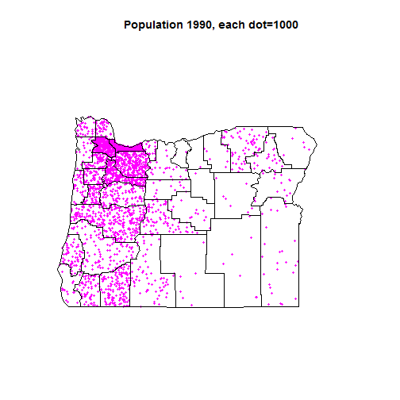

```r
# maptools dot-density maps warning: this can take a little while
plottitle <- "Population 1990, each dot=1000"
orpolys <- SpatialPolygonsDataFrame(orcounty.shp, data = as(orcounty.shp, "data.frame"))
plotvar <- orpolys@data$POP1990/1000

dots.rand <- dotsInPolys(orpolys, as.integer(plotvar), f = "random")
plot(orpolys, xlim = c(-124.5, -115), ylim = c(42, 47))
plot(dots.rand, add = T, pch = 19, cex = 0.5, col = "magenta")
plot(orpolys, add = T)
title(plottitle)
```

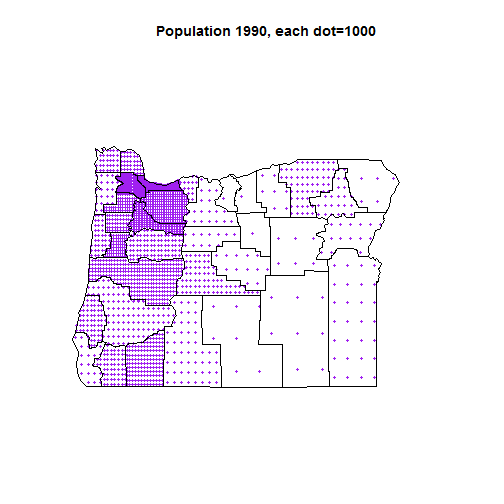

```r
dots.reg <- dotsInPolys(orpolys, as.integer(plotvar), f = "regular")
plot(orpolys, xlim = c(-124.5, -115), ylim = c(42, 47))
plot(dots.reg, add = T, pch = 19, cex = 0.5, col = "purple")
plot(orpolys, add = T)
title(plottitle)
```